# DataExplorer Package for basic EDA

# Introduction

DataExplorer is R package for exploratory data analysis. It helps to visualize data and create report from EDA.

```r
library(DataExplorer)
library(rmarkdown)
library(data.table)
library(ggplot2)
```

```r
speed = read.csv("C://Users/Ajinkya/Dropbox/Machine_Learning/Kaggle/seattle-broadband-speed-test/broadband-speed-test.csv", stringsAsFactors = FALSE)
```

# introduce

it is a simple function which give basic statistics such as row and column number, number of discrete and continuous columns, total observations and missing value count.

```r
introduce(speed)
```

```
##   rows columns discrete_columns continuous_columns all_missing_columns
## 1 4068      13                5                  8                   0
##   total_missing_values total_observations memory_usage
## 1                 7519              52884       663112
```

# plot_str

This function helps to visualize data structure in network graph format.

[figure not shown]

```r
plot_str(speed)
```

Default plot type is diagonal. Other plot type is Radial.

[figure not shown]

```r
plot_str(speed, type = "radial")
```

# drop_columns

As name suggest, this function is used to remove columns from dataset. for data.table object, drop_columns performs inline operation. it removes column from data.table object and assign it back to original dataset.

```r
speed_copy = data.table(speed)
drop_columns(speed_copy, "seattle_blkgrpce10")
colnames(speed_copy)
```

```
##  [1] "id"                  "actual_download"     "actual_upload"
##  [4] "advertised_download" "advertised_upload"   "connection_type"
##  [7] "cost_of_service"     "date_pretty"         "isp"
## [10] "isp_user"            "min_rtt"             "timestamp"
```

In case of data frame object (other than data.table object) this function returns data frame after removing mentioned columns.

```r
speed_v1 = drop_columns(speed, c("id", "timestamp", "seattle_blkgrpce10"))
colnames(speed)
```

```
##  [1] "id"                  "actual_download"     "actual_upload"
##  [4] "advertised_download" "advertised_upload"   "connection_type"
##  [7] "cost_of_service"     "date_pretty"         "isp"
## [10] "isp_user"            "min_rtt"             "timestamp"
## [13] "seattle_blkgrpce10"
```

# plot_missing

it returns count of missing value per variable as bar plot

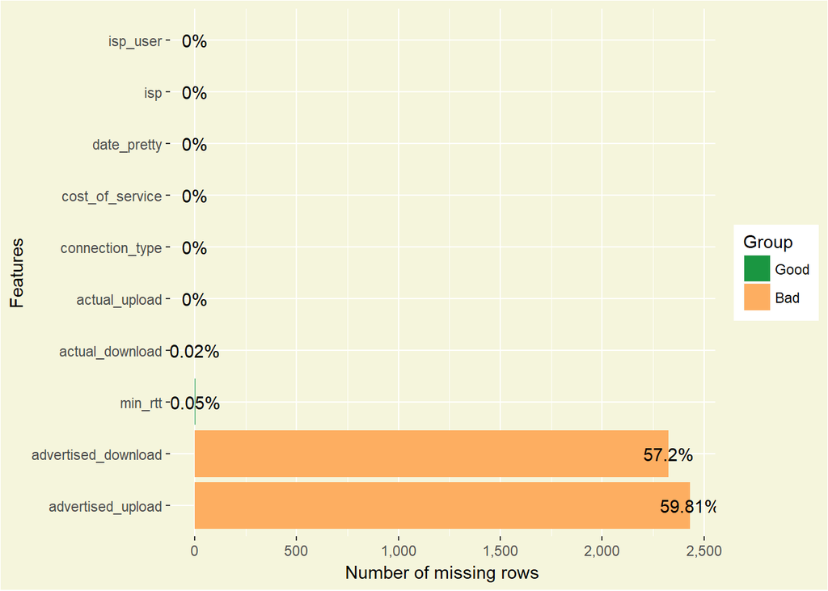

```r
plot_missing(speed_v1,
             theme_config = list("plot.background" = element_rect(fill = "beige"),
                                     "panel.background" = element_rect(fill = "beige")))
```

# set_missing

It helps to set missing values. We can set values to several column together while ignoring other.

```r
speed_v1 = set_missing(speed_v1,
                       as.integer(mean(c(speed$advertised_download,speed$advertised_upload),
                                           na.rm = TRUE, trim=0.01)),
                    exclude = c('min_rtt', 'actual_download'))
```

```
## Column [advertised_download]: Set 2327 missing values to 163
```

```
## Column [advertised_upload]: Set 2433 missing values to 163
```

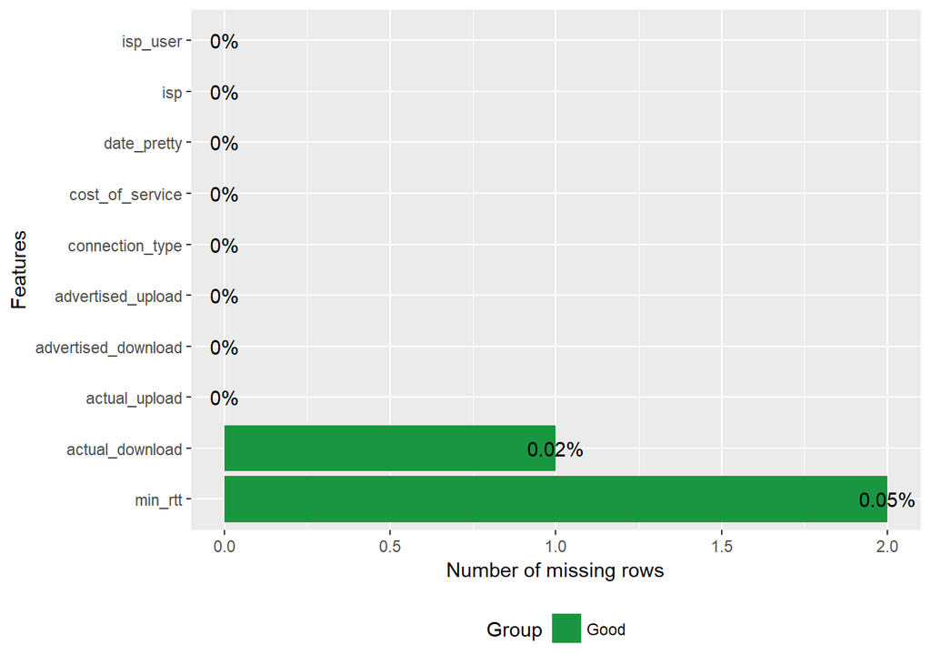

```r
plot_missing(speed_v1)
```

i replace null values in ‘advertised_download’ and ‘advertised_upload’ column with mean of both columns combined (ignored 1% of outlier values on both side)

```r
speed_v1 = set_missing(speed_v1,as.integer(mean(speed$min_rtt,trim=0.01,na.rm=TRUE)),
                    exclude='actual_download')
```

```
## Column [min_rtt]: Set 2 missing values to 23
```

```r
speed_v1 = set_missing(speed_v1,as.integer(mean(speed$actual_download,trim=0.01,na.rm=TRUE)))
```

```
## Column [actual_download]: Set 1 missing values to 42
```

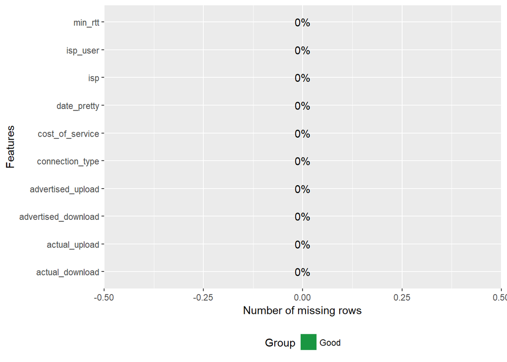

```r
plot_missing(speed_v1)
```

# group_category

This function helps to group categories of discrete variable with very few observations.

```r
unique(speed_v1$cost_of_service)
```

```
## [1] "dont_know"    "50_75"        "100_or_above" "75_100"
## [5] "25_50"        "less_than_25"
```

```r
sort(table(speed_v1$cost_of_service), decreasing=TRUE)
```

```
##
##        50_75       75_100 100_or_above        25_50    dont_know
##         1296          857          722          715          358
## less_than_25
##          120
```

category “dont know” and “less_than_25” combined has 478 observations which is 11% of observation. if we want to combine these two categories for our analysis then we can use group_category function.

```r
speed_merge_cat <- group_category(data=speed_v1, feature = "cost_of_service", threshold = 0.11,                                           category_name = "0_25", update = TRUE)
sort(table(speed_merge_cat$cost_of_service), decreasing=TRUE)
```

```
##
##        50_75       75_100 100_or_above        25_50         0_25
##         1296          857          722          715          478
```

above mentioned two categories are merged and created new category named “0_25”

# plot_boxplot

to plot boxplot of all variables.

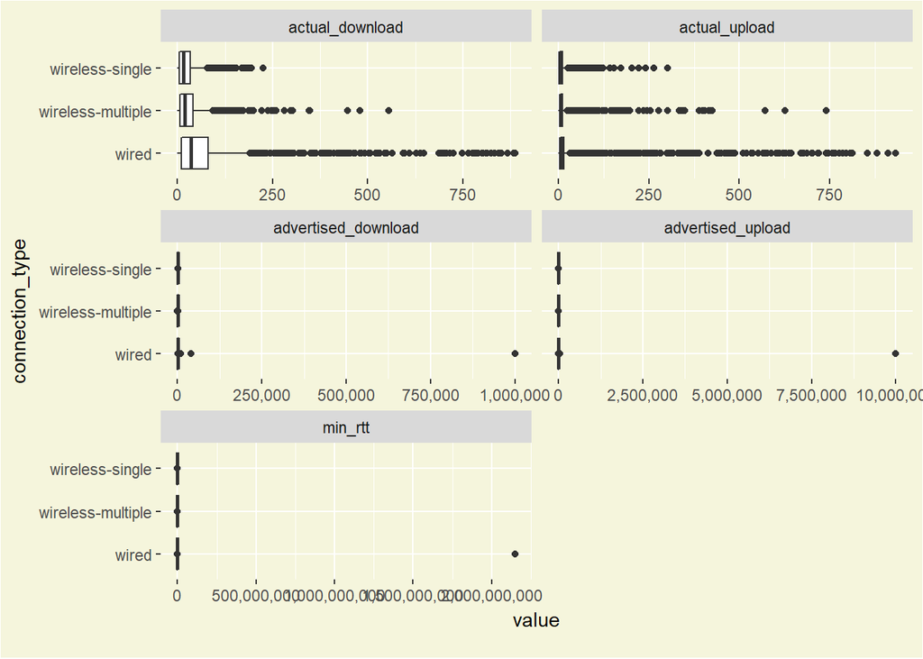

```r
plot_boxplot(speed_v1[c('actual_download','actual_upload','advertised_download',
                        'advertised_upload', 'min_rtt', 'connection_type')],
             by="connection_type",
             theme_config = list("plot.background" = element_rect(fill = "beige"),
                             "panel.background" = element_rect(fill = "beige")))
```

We can see that there are very few high values for ‘advertised download’, ‘advertised upload’, and ‘min_rtt’. I drop those values and plot boxplot again

```r
# dataframe dimension befor dropping observations
dim(speed_v1)
```

```
## [1] 4068   10
```

```r
speed_v1 <- speed_v1[!((speed_v1['advertised_download'] > 100000) |
                     (speed_v1['advertised_upload'] > 100000) | (speed_v1['min_rtt'] > 100000)),]
dim(speed_v1)
```

```
## [1] 4066   10
```

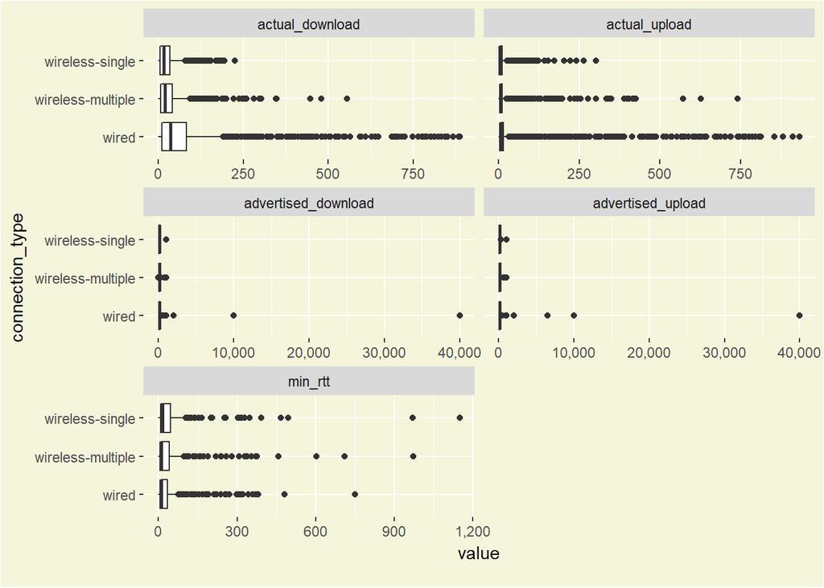

```r
plot_boxplot(speed_v1[c('actual_download','actual_upload','advertised_download',
                        'advertised_upload', 'min_rtt', 'connection_type')], by="connection_type",
             theme_config = list("plot.background" = element_rect(fill = "beige"),
                             "panel.background" = element_rect(fill = "beige")))
```

# plot_correlation

to plot correlation heatmap

```
## 3 features with more than 20 categories ignored!
## date_pretty: 4037 categories
## isp: 217 categories
## isp_user: 218 categories
```

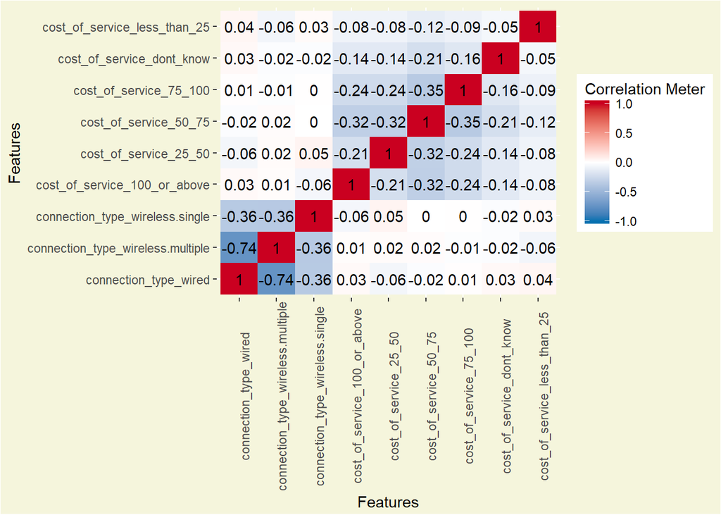

```r
plot_correlation(speed_v1, type = "d",
                 theme_config = list("plot.background" = element_rect(fill = "beige"),
                                     "panel.background" = element_rect(fill = "beige"),
                                     "axis.text.x" = element_text(angle = 90)))
```

you can pass “all”, “continuous”, “discrete” to type variable

# plot_bar

creates frequency bar chart for discrete variables.

```
## 3 columns ignored with more than 50 categories.
## date_pretty: 4037 categories
## isp: 217 categories
## isp_user: 218 categories
```

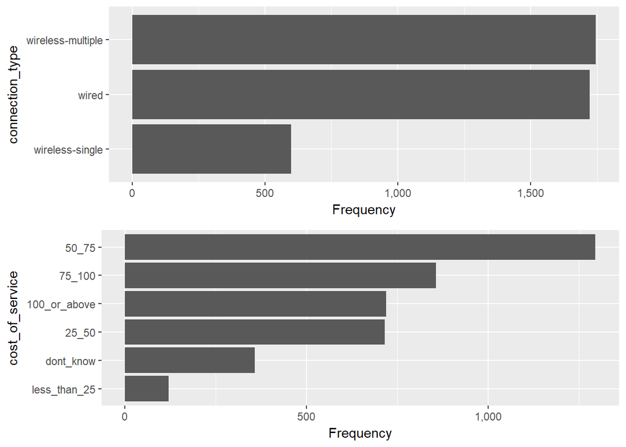

```r
plot_bar(speed_v1)
```

by default it plots for variable with 50 categories. But we can change that with maxcat parameter. we can also apply different ggplot themes using ggtheme parameter.

```
## 4 columns ignored with more than 5 categories.
## cost_of_service: 6 categories
## date_pretty: 4037 categories
## isp: 217 categories
## isp_user: 218 categories
```

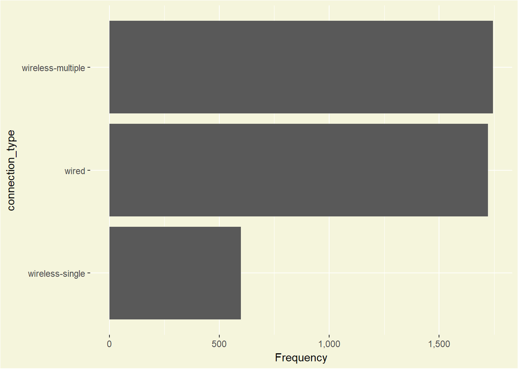

```r
plot_bar(speed_v1, maxcat = 5,
         theme_config = list("plot.background" = element_rect(fill = "beige"),
                             "panel.background" = element_rect(fill = "beige")))
```

# plot_density

it plots density distribution of all continuous variables.

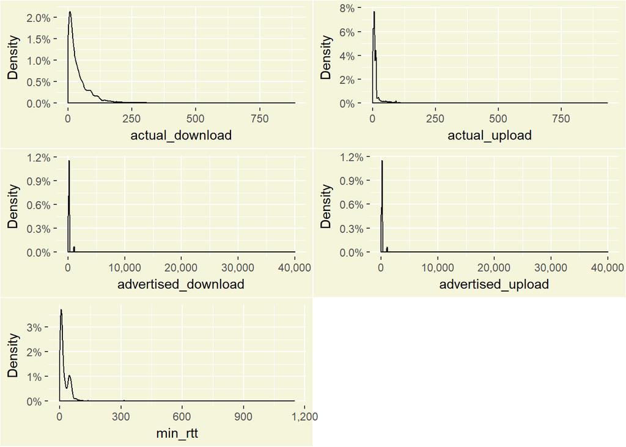

```r
plot_density(speed_v1,
             theme_config = list("plot.background" = element_rect(fill = "beige"),
                                     "panel.background" = element_rect(fill = "beige")))
```

# plot_histogram

plots histogram for continuous variables

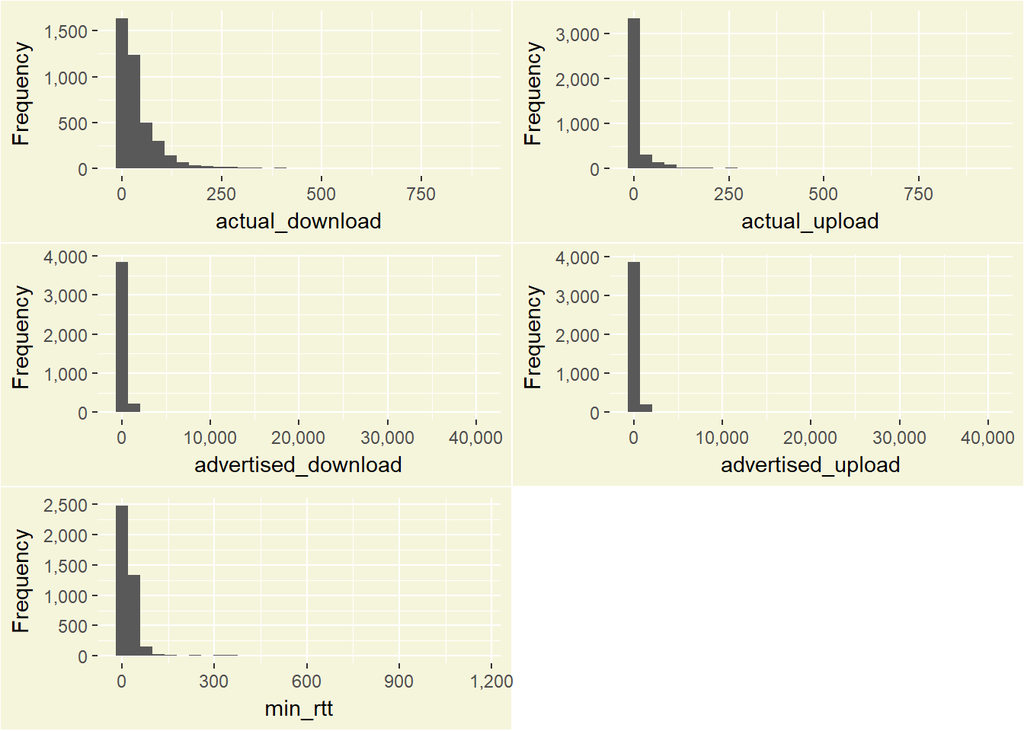

```r
plot_histogram(speed_v1,
               theme_config = list("plot.background" = element_rect(fill = "beige"),
                                     "panel.background" = element_rect(fill = "beige")))
```

# plot_scatterplot

This function plots scatterplot by fixing one axis to one perticular variable in dataset.

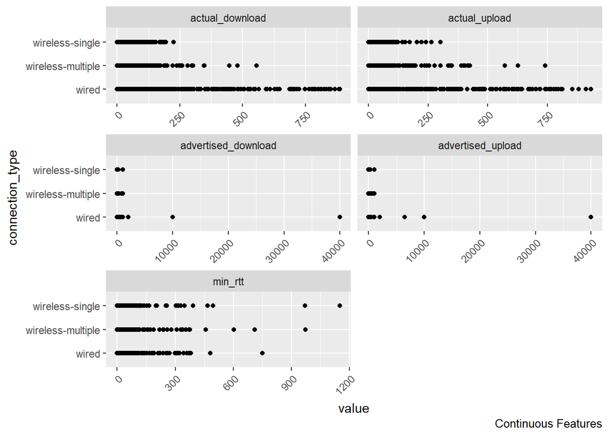

[figure not shown]

```r
plot_scatterplot(speed_v1, by="connection_type")
```

# plot_prcomp

this function plot output of prcomp

```
## 3 features with more than 50 categories ignored!
## date_pretty: 4037 categories
## isp: 217 categories
## isp_user: 218 categories
```

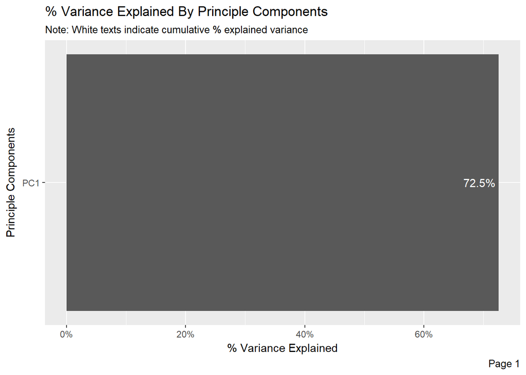

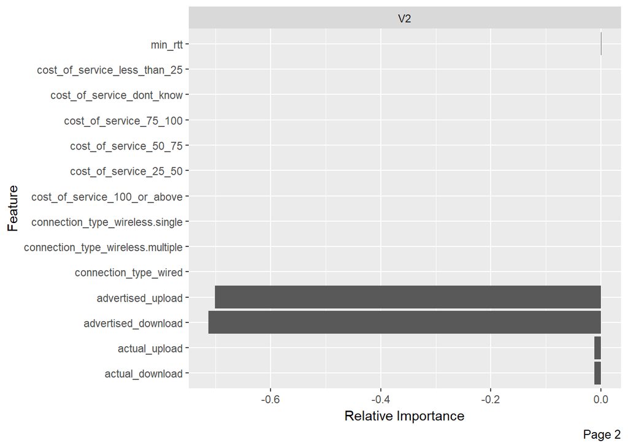

```r
plot_prcomp(speed_v1)
```

Parameter variance_cap helps to decide which principal components to plot. Default value for this is 80% which means it plots principal components which explain 80% cumulative variation in dataset. If you want to see all principal components then put variance_cap = 1.

```
## 3 features with more than 50 categories ignored!
## date_pretty: 4037 categories
## isp: 217 categories
## isp_user: 218 categories
```

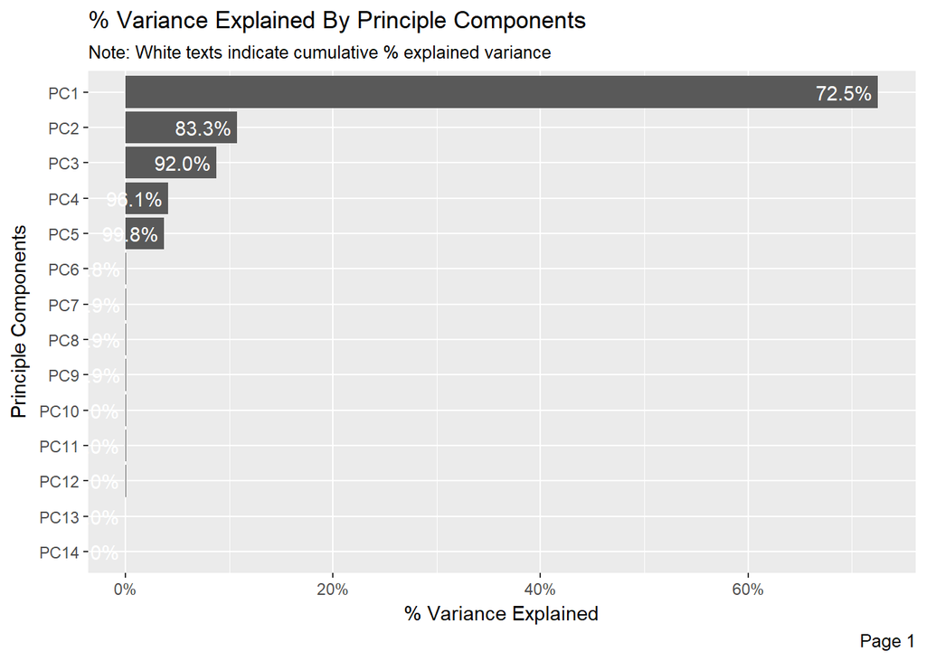

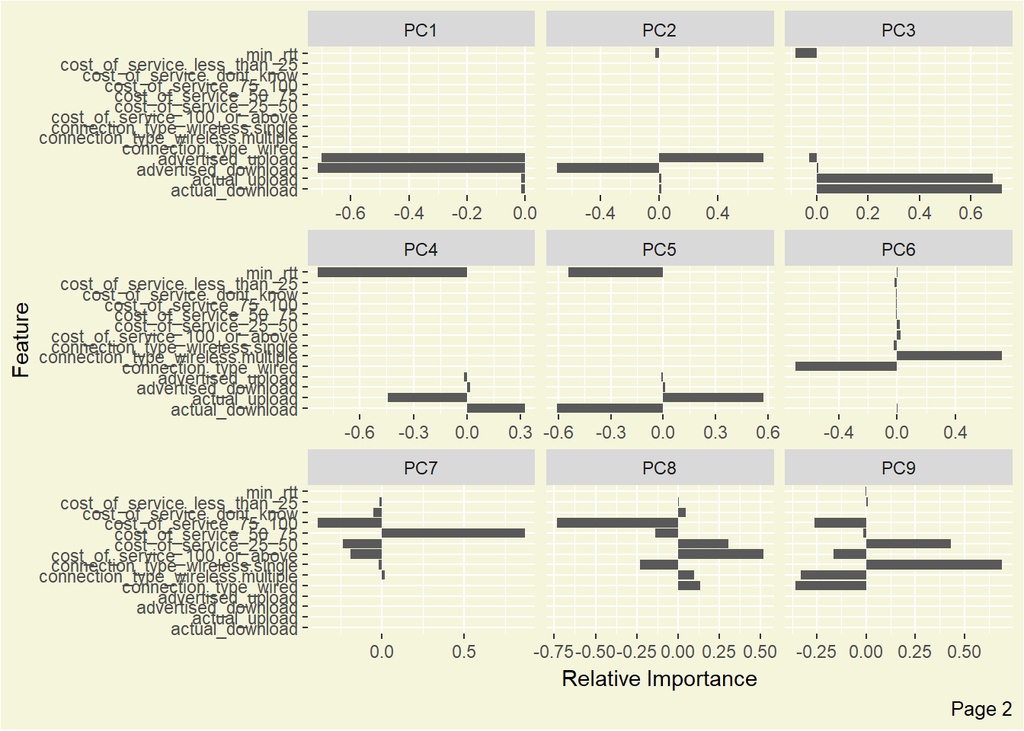

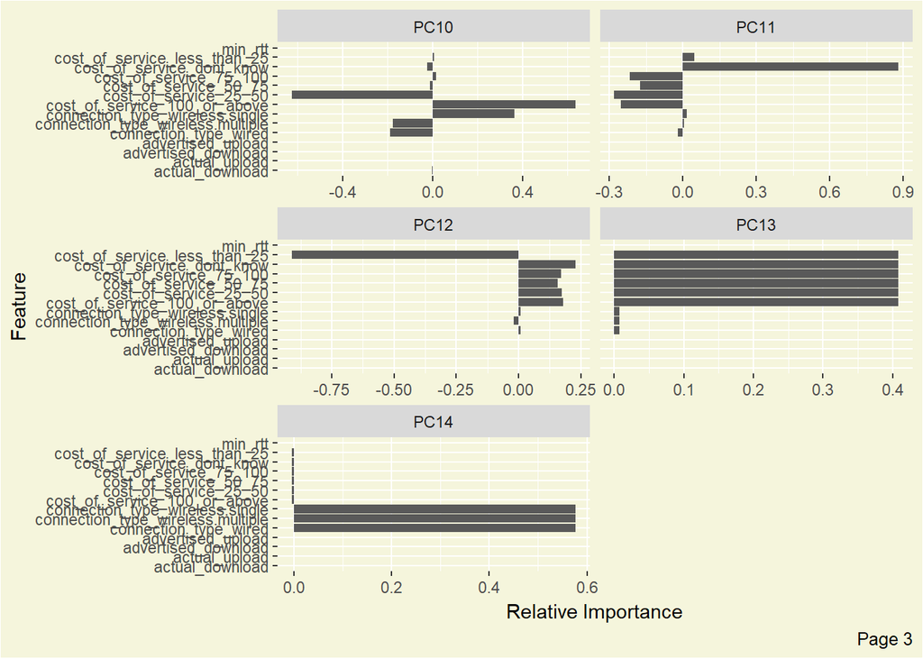

```r
plot_prcomp(speed_v1, variance_cap = 1,
            theme_config = list("plot.background" = element_rect(fill = "beige"),
                                     "panel.background" = element_rect(fill = "beige")))
```

# split_columns

This function divides dataset by column type into 2 different data.table objects i.e. discrete and continuous. If column type is numeric then it is continuous.

```r
output = split_columns(speed_v1)
```

```r
str(output$discrete)
```

```
## 'data.frame':    4066 obs. of  5 variables:
##  $ connection_type: chr  "wired" "wireless-single" "wireless-single" "wireless-multiple" ...
##  $ cost_of_service: chr  "dont_know" "50_75" "100_or_above" "100_or_above" ...
##  $ date_pretty    : chr  "Wed, 10 Feb 2016 12:58:16 GMT" "Wed, 10 Feb 2016 13:56:47 GMT" "Wed, 10 Feb 2016 13:58:08 GMT" "Wed, 10 Feb 2016 14:43:11 GMT" ...
##  $ isp            : chr  "AS2828 MCI Communications Services, Inc. d/b/a Verizon Business" "AS174 Cogent Communications" "AS174 Cogent Communications" "AS174 Cogent Communications" ...
##  $ isp_user       : chr  "XO" "comcast" "comcast" "level3" ...
##  - attr(*, ".internal.selfref")=<externalptr>
```

```r
str(output$continuous)
```

```
## 'data.frame':    4066 obs. of  5 variables:
##  $ actual_download    : num  530.17 24.34 10.34 7.6 9.47 ...
##  $ actual_upload      : num  253.08 48.62 42.77 15.09 0.69 ...
##  $ advertised_download: int  163 163 163 163 163 163 163 163 163 163 ...
##  $ advertised_upload  : int  163 163 163 163 12 163 163 163 163 163 ...
##  $ min_rtt            : int  2 2 2 39 19 10 22 56 26 12 ...
##  - attr(*, ".internal.selfref")=<externalptr>
```

it also gives count of columns with all missing values.

```r
print(output$num_all_missing)
```

```
## [1] 0
```

# dummify

similar to one hot encoding. Convert each category to binary column.

```r
str(speed_v1)
```

```
## 'data.frame':    4066 obs. of  10 variables:
##  $ actual_download    : num  530.17 24.34 10.34 7.6 9.47 ...
##  $ actual_upload      : num  253.08 48.62 42.77 15.09 0.69 ...
##  $ advertised_download: int  163 163 163 163 163 163 163 163 163 163 ...
##  $ advertised_upload  : int  163 163 163 163 12 163 163 163 163 163 ...
##  $ connection_type    : chr  "wired" "wireless-single" "wireless-single" "wireless-multiple" ...
##  $ cost_of_service    : chr  "dont_know" "50_75" "100_or_above" "100_or_above" ...
##  $ date_pretty        : chr  "Wed, 10 Feb 2016 12:58:16 GMT" "Wed, 10 Feb 2016 13:56:47 GMT" "Wed, 10 Feb 2016 13:58:08 GMT" "Wed, 10 Feb 2016 14:43:11 GMT" ...
##  $ isp                : chr  "AS2828 MCI Communications Services, Inc. d/b/a Verizon Business" "AS174 Cogent Communications" "AS174 Cogent Communications" "AS174 Cogent Communications" ...
##  $ isp_user           : chr  "XO" "comcast" "comcast" "level3" ...
##  $ min_rtt            : int  2 2 2 39 19 10 22 56 26 12 ...
##  - attr(*, ".internal.selfref")=<externalptr>
```

```r
speed_dummy = dummify(speed_v1, maxcat = 10)
```

```
## 3 features with more than 10 categories ignored!
## date_pretty: 4037 categories
## isp: 217 categories
## isp_user: 218 categories
```

```r
colnames(speed_dummy)
```

```
##  [1] "actual_download"
##  [2] "actual_upload"
##  [3] "advertised_download"
##  [4] "advertised_upload"
##  [5] "min_rtt"
##  [6] "date_pretty"
##  [7] "isp"
##  [8] "isp_user"
##  [9] "connection_type_wired"
## [10] "connection_type_wireless.multiple"
## [11] "connection_type_wireless.single"
## [12] "cost_of_service_100_or_above"
## [13] "cost_of_service_25_50"
## [14] "cost_of_service_50_75"
## [15] "cost_of_service_75_100"
## [16] "cost_of_service_dont_know"
## [17] "cost_of_service_less_than_25"
```

maxcat is maximum categories allowed. if there is column with more than 10 discrete values then it will be ignored. Default value for maxcat is 50.

# create_report

This function summerizes all above functions in nice report format.

```r
create_report(speed)
```

[Report](https://github.com/Ajinkya45/DataExplorer-Package-explained-with-Seattle-Broadband-speed-dataset/blob/master/Reports/report_v1.pdf)

This is first report with no data processing steps applied. By default create_report function provides basic dataset statistics such as **row and column count**, **missing data count**, **name and data types of columns**, **univariate plot of each variable**, **correlation analysis** and **principle component analysis**. Great thing about this package is that you can customize this report as per your need. config paramaeter in function allows you to keep only those analysis of dataset which you want in your report. Default config setting:

```r
config <- list(
"introduce" = list(),
"plot_str" = list(
"type" = "diagonal",
"fontSize" = 35,
"width" = 1000,
"margin" = list("left" = 350, "right" = 250)
),
"plot_missing" = list(),
"plot_histogram" = list(),
"plot_bar" = list(),
"plot_correlation" = list("use" = "pairwise.complete.obs"),
"plot_prcomp" = list(),
"plot_boxplot" = list(),
"plot_scatterplot" = list()
)
```

```r
create_report(speed_v1, output_file = "report.html", output_dir = getwd(), y="connection_type",
              config = list("introduce" = list(),
                                   "plot_str" = list("type" = "radial",
                                                     "fontSize" = 35,
                                                     "width" = 1000,
                                                     "margin" = list("left" = 350, "right" = 250)
                                                     ),
                                   "plot_missing" = list(),
                                   "plot_correlation" = list()
                                   ),
              html_document(toc = TRUE, toc_depth = 6, theme = "united")
              )
```

[Report](https://github.com/Ajinkya45/DataExplorer-Package-explained-with-Seattle-Broadband-speed-dataset/blob/master/Reports/report_v2.pdf)